# Clone detection stuff

> These graphs are not checked yet

### Configuration

Edit this to update the notebook to your needs.

```r
INPUT_DIR <- "/home/peta/sourcerer/reporting/aws_withminjs_v6"
#INPUT_DIR <- "/home/peta/sourcerer/reporting/jakub2"
```

### Importing data

This imports the scripts for loading data and some basic graphs.

```r
source("clone_detection.r")
source("graphs.r")
```

Load the data now:

```r
tokens <- read.tokens(paste(INPUT_DIR, "/tokens.txt", sep = ""))
```

## Token Frequencies

```r
summary(tokens$count)
```

```
    Min.  1st Qu.   Median     Mean  3rd Qu.     Max.
       1        1        2      111        8 15090000
```

Seems like most tokens do not appear in lot of files, however it is interesting to see that more than 50% of the tokens actually appear it at least 2 files. For smaller datasets, such as `jakub2` with 1000 projects this is not the case and more than 50% of tokens have only one use, so perhaps this is an artifact of having too much data…

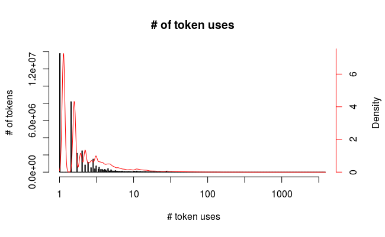

```r
logHist(tokens$count, main = "# of token uses", xlab = " # token uses", ylab = "# of tokens", base = 100)
```

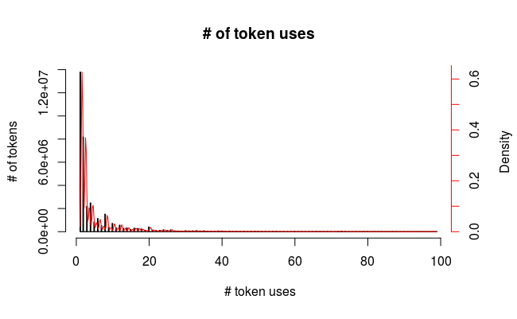

```r
normalHist(tokens$count [ tokens$count < 100], main = "# of token uses", xlab = " # token uses", ylab = "# of tokens")
```

As expected, the graph is dominated by tokens that have very little repetition, so next graphs ignore these and look at the range with more than 50 and less than 10000 uses:

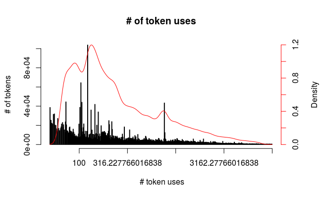

```r
logHist(tokens$count [ tokens$count %in% 50:10000], main = "# of token uses", xlab = " # token uses", ylab = "# of tokens")
```

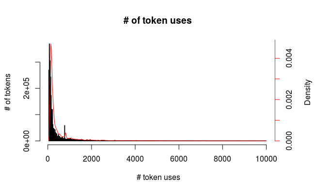

```r
normalHist(tokens$count [ tokens$count %in% 50:10000], main = "# of token uses", xlab = " # token uses", ylab = "# of tokens")
```

Some of the spikes are weird, lets look at what they are…

```r
spikedTokens <- tokens[tokens$count == 123,]
```

Summary:

```r
summary(spikedTokens)
```

```
       id               count         text              textSize
 Min.   :   20013   Min.   :123   Length:97202       Min.   :    3.00
 1st Qu.:  882302   1st Qu.:123   Class :character   1st Qu.:   10.00
 Median :  918648   Median :123   Mode  :character   Median :   11.00
 Mean   : 1485143   Mean   :123                      Mean   :   12.64
 3rd Qu.:  957851   3rd Qu.:123                      3rd Qu.:   12.00
 Max.   :39228294   Max.   :123                      Max.   :17862.00
```

Histograms of its tokens size:

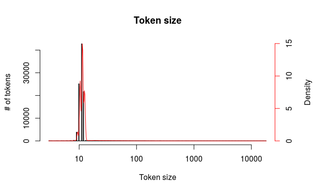

```r
logHist(spikedTokens$textSize, main = "Token size", xlab = "Token size", ylab = "# of tokens")
```

Now, let’s look at what some of them are, say sizes from 8 to 15:

```r
tmp <- spikedTokens[spikedTokens$textSize %in% 8:15,]
tmp <- sapply(tmp$text, unescape, USE.NAMES = F)
ttype = sapply(tmp, tokenType, USE.NAMES = F)
summary(as.factor(ttype))
```

```
character     ident    number   regexpr
      364       784     93098         4
```

That is a lot of numbers… Perhaps it has something to do with precisssion… The spikes might need more investigating

So, what are the most frequent tokens? Here is top 100:

```r
x <- tokens[head(order(-tokens$count),100),]
x$text <- sapply(x$text, unescape)
subset(x, select = c("text", "count"))
```

|  | text | count |
| --- | --- | --- |
| 15036125 | function | 15085409 |
| 35600786 | var | 13797052 |
| 15039250 | return | 12011797 |
| 10437906 | 0 | 11449731 |
| 8735281 | if | 10910997 |
| 28831313 | 1 | 10407584 |
| 18761043 | this | 7568504 |
| 14201797 | length | 7365793 |
| 15189139 | 2 | 6989168 |
| 15727083 | else | 6579660 |

[output cut: 90 more lines]

This does not seem too surprising, but is a nice validation. “Interesting” result might be that single quotes seem to be more popular than double quotes.